# Group 5: Table manners and epidemics

Egydio Pacheco Neto

Fabio Baldivia Pohl

Gabriel Eduardo Moyano

Giovana Oshiro da Silva

Norma Rocio Forero Muñoz

Raul Ossada

Rodrigo Malavazi Corder

2018 January 18

Link to Github Repository: https://github.com/raulossada/ift_2018

# 1 INTRODUCTION

It is very difficult to pronounciate Zoochlorella. (guestimate)

Zoochlorella are algae.

Paramecium is a cilliate protist.

Paramecium endosymbiosis with Zoochlorella.

Didinium is a specialist predator of Paramecium. Messy Feeding and Full Feeding

Chlorovirus is a large DNA, that can’t attack Zoochlorellas that are inside a Paramecium

# 2 MATERIALS AND METHODS

## 2.1 Model Hipothesis

What we didn’t include?

1. Due to the high growth rate of Zoochlorella inside of a Paramecium we assume that this population reaches its maximum
2. Handling Time (Didinium is a voracious predator)

What we included?

1. Logistic growth rates
2. Didinium is a specific predator
3. Increased chance for a Chorovirus attached to the membrane of a Paramecium to infect a Zoochlorella that was inside it
4. Messy feeding effect due larger size of Paramecium with Zoochlorella
5. Endosymbiosis between Zoochlorella and Paramecium

## 2.2 Equations

$$\begin{align*}
\frac{dZ}{dt}&=r_{Z} Z \left(1-\frac{Z}{K_{Z}}\right) + (1-\alpha) g (w D + m_{P_{Z}}) P_{Z} - s Z P - i Z C \\
\frac{dP}{dt}&=r_{P} P \left(1-\frac{P}{K_{P}}\right) - h s Z P - u j P D \\
\frac{dP_{Z}}{dt}&=r_{P_{z}} P_{z} \left(1-\frac{P_{Z}}{K_{P_{Z}}}\right) + h s Z P - j P_{Z} D \\
\frac{dD}{dt}&=e j (u P + P_{Z}) D - m_{D} D \\
\frac{dC}{dt}&=b i Z C + b \alpha g (w D + m_{P_{Z}}) P_{Z} C - m_{C} C
\end{align*}$$

## 2.3 Numerical Aproximation

```r
# libraries
library('deSolve');
library('reshape2');
library('ggplot2');
library('ggthemes');
library('scales');

# time sequence
time <- seq(from=0, to=300, by=0.01);

# parameters
parameters <- c(r_Z=0.9,
                r_P=0.6,
                r_Pz=0.9,
                K_z=5000,
                K_P=1000,
                K_Pz=1200,
                m_Pz=0.001,
                m_D=0.4,
                m_C=0.6,
                s=0.6,
                i=0.05,
                e=0.2,
                j=0.01,
                q=0.3,
                g=500,
                alpha=0,
                h=0.1,
                b=1,
                u=1);

# m1 = q*p
# m2+f2 = p
# m1+f1= p
# ,
# m1=0.75,
# m2=0.30,
# f1=0.25,
# f2=0.70

# model
model1 <- function(t, state, parameters){
  with( as.list( c(state, parameters) ), {

    w <- q*j;
    dZ  <- r_Z*Z*(1-Z/K_z) + (1-alpha)*g*(w*D + m_Pz)*Pz - s*Z*P - i*Z*C;
    dP  <- r_P*P*(1-P/K_P) - h*s*Z*P - (u*j)*P*D;
    dPz <- r_Pz*Pz*(1-Pz/K_Pz) + h*s*Z*P - (j)*Pz*D;
    dD  <- e*j*( u*P + Pz )*D - m_D*D;
    dC  <- b*i*Z*C + b*alpha*g*(w*D + m_Pz)*Pz*C - m_C*C;

    return( list( c(dZ, dP, dPz, dD, dC) ) );
  })
}

# initial conditions
state <- c(Z=10, P=10, Pz=0, D=1, C=1);

# Numerical solution
res <- ode(y=state, times=time, func=model1, parms=parameters, method='lsoda');
```

# 3 RESULTS

```r
# Plot
res_df <- as.data.frame(x=res);
res_m <- melt(data=res_df, id.vars='time');
```

### Plot of all populations

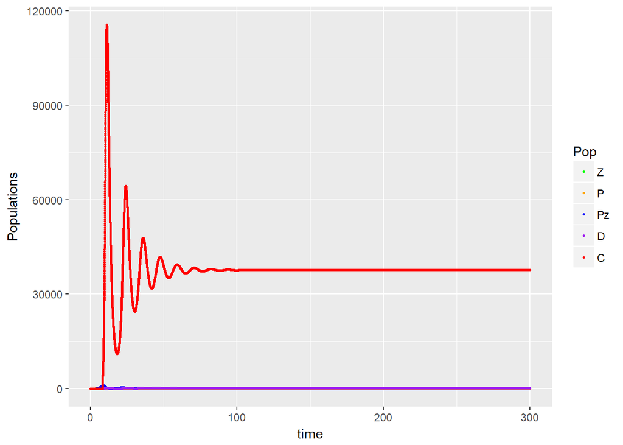

```r
p <- ggplot(data=res_m, mapping=aes(x=time, y=value, color=variable ) ) +
  geom_point(size=0.5) +
  scale_color_manual(breaks=c("Z", "P", "Pz", "D", "C"), values=c("green", "orange", "blue", "purple", "red") ) +
  labs(y='Populations', color='Pop');
print(p);
```

### Plot of the Zoochlorella Population

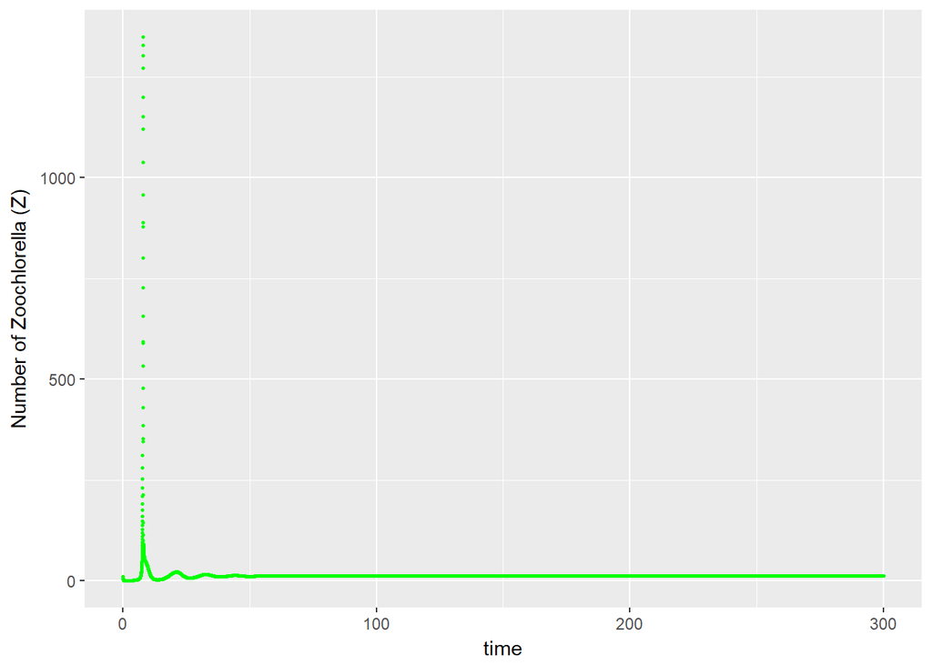

```r
Z_m <- res_m[which(res_m$variable=='Z'), ];
p_Z <- ggplot(data=Z_m, mapping=aes(x=time, y=value) ) +
  geom_point(size=0.5, col='green') +
  labs(y='Number of Zoochlorella (Z)');
print(p_Z);
```

### Plot of the Paramecium Population

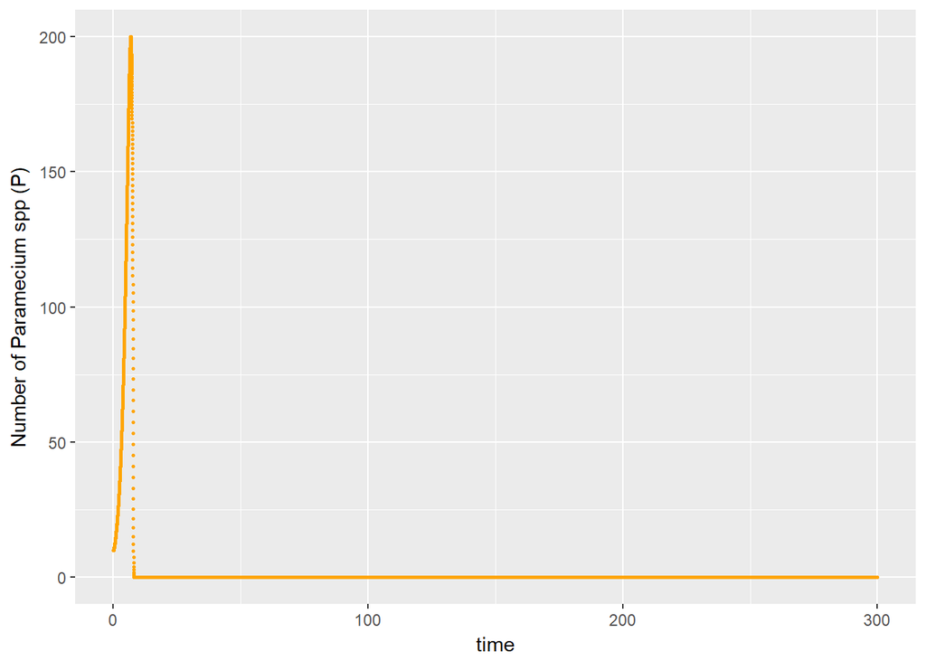

```r
P_m <- res_m[which(res_m$variable=='P'), ];
p_P <- ggplot(data=P_m, mapping=aes(x=time, y=value) ) +
  geom_point(size=0.5, col='orange') +
  labs(y='Number of Paramecium spp (P)');
print(p_P);
```

### Plot of the Paramecium with Zoochlorella Population

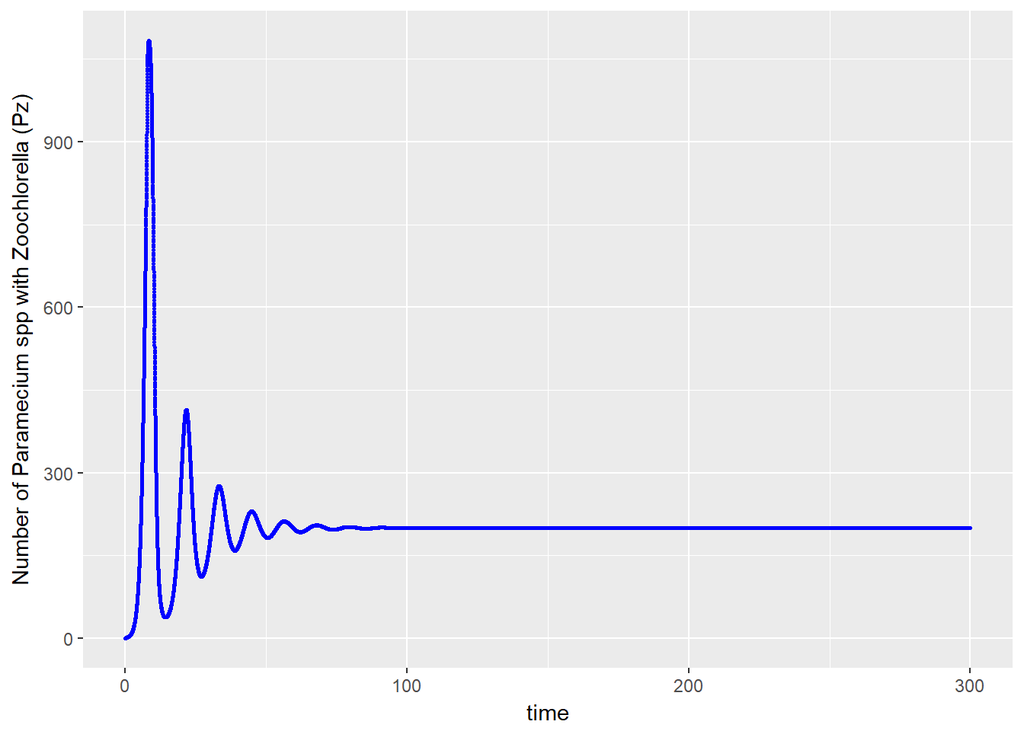

```r
Pz_m <- res_m[which(res_m$variable=='Pz'), ];
p_Pz <- ggplot(data=Pz_m, mapping=aes(x=time, y=value) ) +
  geom_point(size=0.5, col='blue') +
  labs(y='Number of Paramecium spp with Zoochlorella (Pz)');
print(p_Pz);
```

### Plot of the Didinium Population

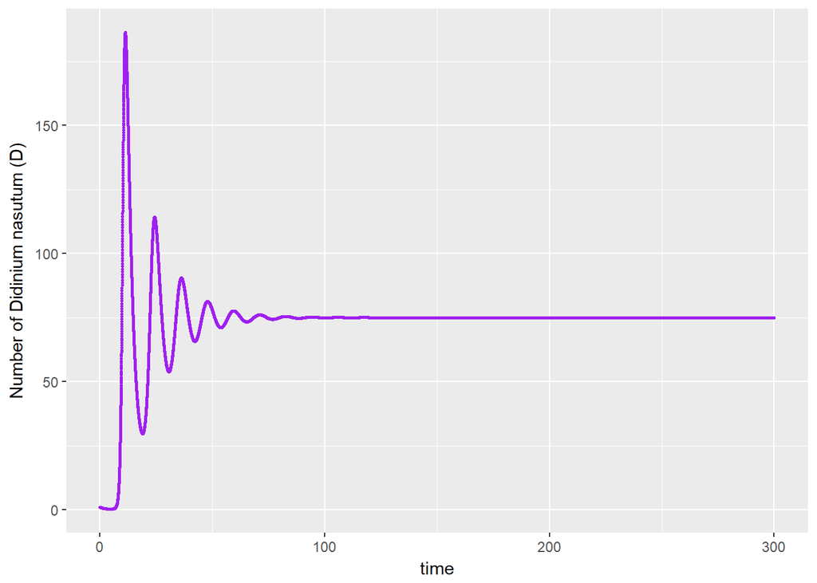

```r
D_m <- res_m[which(res_m$variable=='D'), ];
p_D <- ggplot(data=D_m, mapping=aes(x=time, y=value) ) +
  geom_point(size=0.5, col='purple') +
  labs(y='Number of Didinium nasutum (D)');
print(p_D);
```

### Plot of the Chlorovirus Population

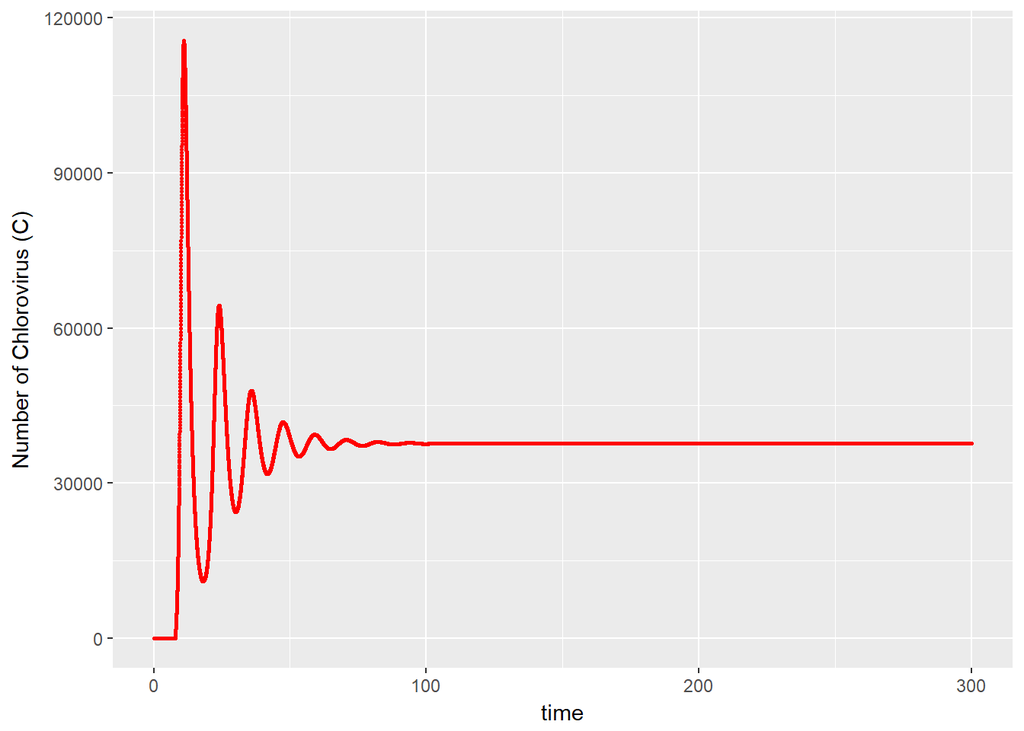

```r
C_m <- res_m[which(res_m$variable=='C'), ];
p_C <- ggplot(data=C_m, mapping=aes(x=time, y=value) ) +
  geom_point(size=0.5, col='red') +
  labs(y='Number of Chlorovirus (C)');
print(p_C);
```

# 4 DISCUSSION

# 5 CONCLUSIONS

# 6 Acknowledgements

The authors thanks John P. DeLong for the support in the development of the project.

# 7 REFERENCES

[1] DeLong J. P., Al-Ammedi Z., Lyon S., Van Etten J. L. and Dunigan D. D. [Size-dependent catalysis of Chlorovirus population growth by a messy feeding predator](https://link.springer.com/article/10.1007%2Fs00248-017-1106-8). Microbial Ecology, November 2017.

[2] Cáceres C. E., Knight C. J. and Hall S. R. [Predator-spreaders: predation can enhance parasite success in a planktonic host-parasite system](http://onlinelibrary.wiley.com/doi/10.1890/08-2154.1/abstract). Ecology, 2009.

# Appendix A

## Silly simulation 1

```r
# initial conditions
state <- c(Z=0, P=0, Pz=0, D=0, C=0);
```

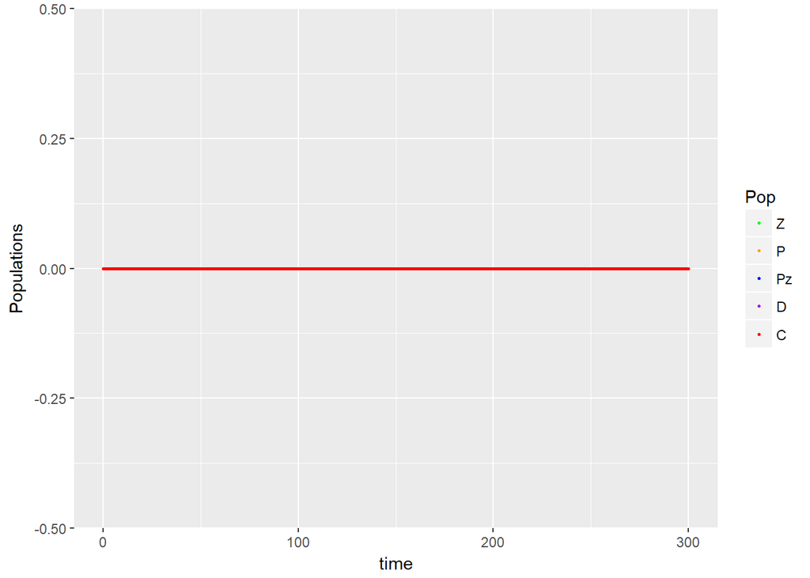

## Silly simulation 2

```r
# initial conditions
state <- c(Z=1, P=0, Pz=0, D=0, C=0);
```

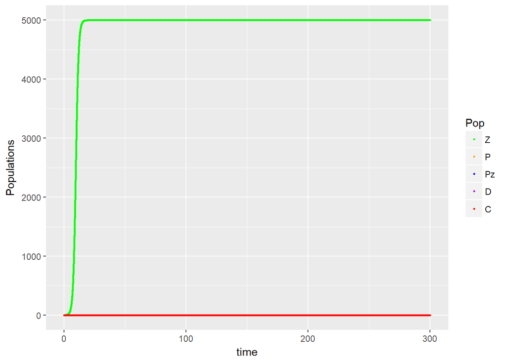

## Silly simulation 3

```r
# initial conditions
state <- c(Z=0, P=1, Pz=0, D=0, C=0);
```

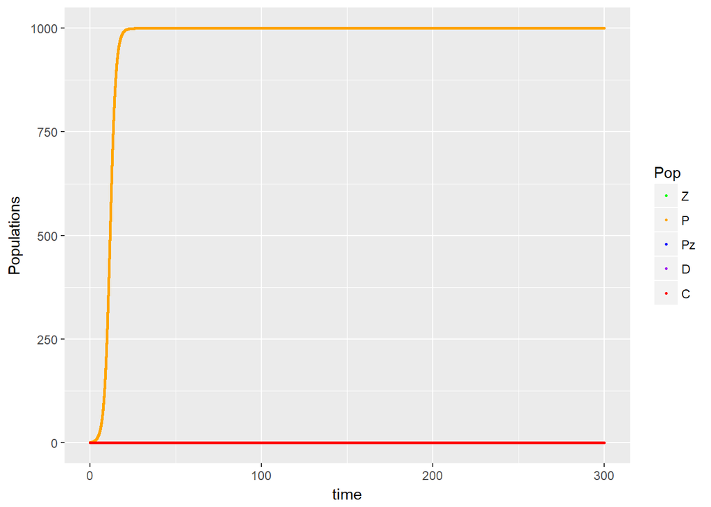

## Silly simulation 4

```r
# initial conditions
state <- c(Z=0, P=0, Pz=1, D=0, C=0);
```

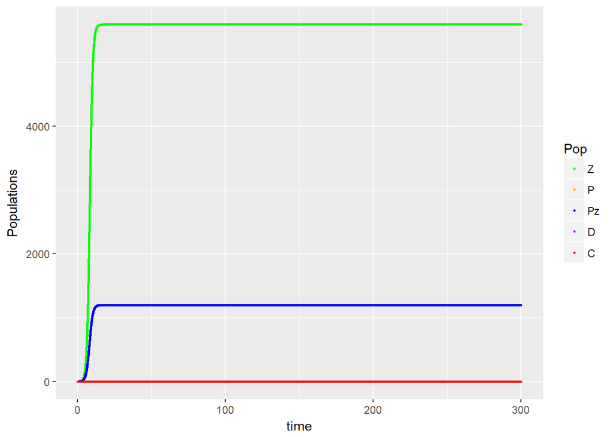

## Silly simulation 5

```r
# initial conditions
state <- c(Z=0, P=0, Pz=0, D=1, C=0);
```

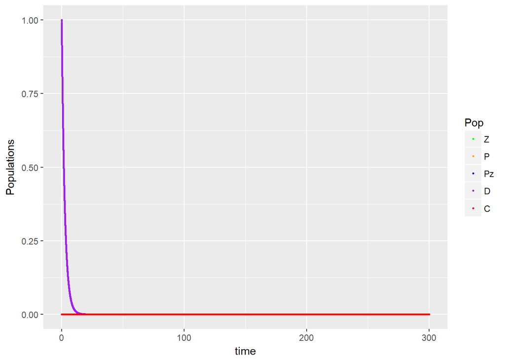

## Silly simulation 6

```r
# initial conditions
state <- c(Z=0, P=0, Pz=0, D=0, C=1);
```

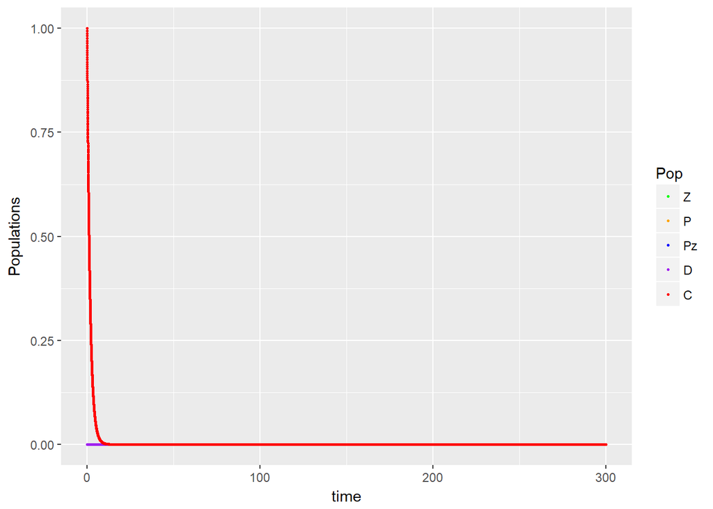